# Using R for Cyclodextrin Affinity Prediction

## Overview

The process for obtaining affinity predictions follows these overarching steps:

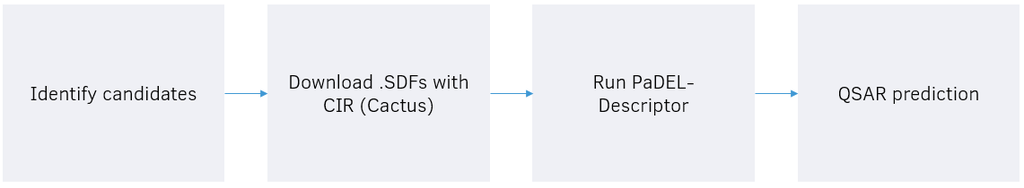

All the steps except using PaDEL-Descriptor are built into the script file `cdap.R`. Fortunately, PaDEL-Descriptor is fairly intuitive, and everything you need to do is detailed here

Currently, this can only be used to predict for alpha- and beta-CD. The value returned by the code is the change in Gibbs free energy (often abbreviated as dG of DelG) of guest-host complexation.

The code used to actually build the models can be found in the repository wip-cactus. Don’t mind the name – it’s a leftover from early steps in the QSAR building process.

## Setting up

Make sure you have RStudio and R installed. On the main page for cdap, click the green button that says **Clone or Download** and select **Download ZIP**. Extract the files somewhere convenient, and open up the script `cdap.R`. You’ll notice that some lines are commented out (i.e., they are preceded by a **#**) and will not run on their own. As you follow through this guide, uncomment these lines as necessary.

The first executable line should be `getwd()`. This will print a filepath to the console – make sure it’s the filepath of the cdap folder. If not, use `setwd("example/example")` to set the working directory to the cdap folder. The next couple lines look something like `source("example.R")`. These will read functions and install the necessary R packages.

```r
# To run lines of code, highlight the section you want to run and either press
# Ctrl + Enter or click the button in the upper right that says "Run"
source("cactus.R")
source("applicability.domain.R")
source("qsar.R")
```

## Structural files

If you already have the structural files for the molecules you want to test, skip to Chemical descriptors

### Names

First, the names of the guest molecules you want to evaluate have to be assigned to a vector. In the easiest scenario, you have only a couple of easily typable names. Assign these to the variable `guests`.

```r
guests <- c("cinnarizine", "diethylamine", "acetaminophen", "piroxicam")

# If there's only one name you need, no need to put it into a vector
guests <- "metformin" # Don't mind that "guests" is technically plural
```

If there are many molecules, it may be easier to use `read.csv`. Write or copy the molecule names into the first column of an Excel document under the header “guests”. Save the file as guests.csv (in the cdap folder) and read it into R.

```r
guests <- read.csv("guests.csv", header = T) %>% .$guests
```

### Structural files with CACTUS

To get the 3D structure files, the names of the molecules have to be fed through the Chemical Identifier Resolver (CIR), essentially a search engine for molecules created by the National Cancer Institute’s CADD Group. (CIR and a variety of other useful programs can be found at [CACTUS](https://cactus.nci.nih.gov/), the **CA**DD Group **C**hemoinformatics **T**ools and **U**ser **S**ervices.)

The function `download.cactus.results` both retrieves a molecule from CIR as well as outputs a data.frame indicating success or failure. The function is designed to only handle one name at a time, so multiple guests must be fed through `do.call` and `lapply`. At this step, it may take multiple tries to get the correct molecule, as some molecules are only searchable under certain names (e.g., you can use CIR with “Tylenol” but not “Actamin”, despite both terms referring to acetominophen). Some more uncommon drugs may be absent from the database entirely.

```r
# Create a folder to hold the molecules
dir.create("guests")

# Download only a single guest molecule
results.dwnld <- download.cactus.results(guests, path = "guests",
                                         chemical.format = "SDF")

# Download multiple guest molecules
results.dwnld <-
  do.call(
    rbind,
    lapply(
      guests,
      download.cactus.results,
      path = filepath,
      chemical.format = "SDF"
    )
  )
```

Take a look at `results.dwnld` to see if any molecules failed to process. If some failed, try again using a chemical synonym. Re-running `download.cactus.results` will not delete any of the existing molecular structure files.

```r
# For small sets of molecules, printing the table to the Console is fine
print(results.dwnld)

# For large sets, you may want to open another window
View(results.dwnld)

# Alternatively, you can retrieve a list of molecules that did not download
guests.failed <- results.dwnld %>% filter(downloaded == "no") %>% .$guest

# To try again, assign a new variable with the modified names
# For example, if the original list of guests failed to download "neomyecin",
# "doxicycline", or "Sumycin", assign the corrected names to guests2
guests2 <- c("neomycin", "doxycycline", "tetracycline")
results.dwnld2 <-
  do.call(
    rbind,
    lapply(
      guests2,
      download.cactus.results,
      path = filepath,
      chemical.format = "SDF"
    )
  )
```

## Chemical descriptors

### Calculation using PaDEL

Make sure you have [PaDEL-Descriptor](http://yapcwsoft.com/dd/padeldescriptor/) and [Java](https://www.java.com/en/download/help/index_installing.xml) installed. Open the executable .jar file in the PaDEL-Descriptor folder (this doesn’t have to be downloaded in the cdap folder, but it might make it easier). Check off the boxes to match the example interface below. Note that “Max. running time per molecule” has been assigned to 200,000 milliseconds. This will prevent the software from stalling for too long on molecules.

If you didn’t go through CIR, depending on how your molecular structure file is saved, the last box – “Use filename as molecule name” – may or may not need to be checked off. If multiple molecules are stored in a single .SDF, uncheck the box.

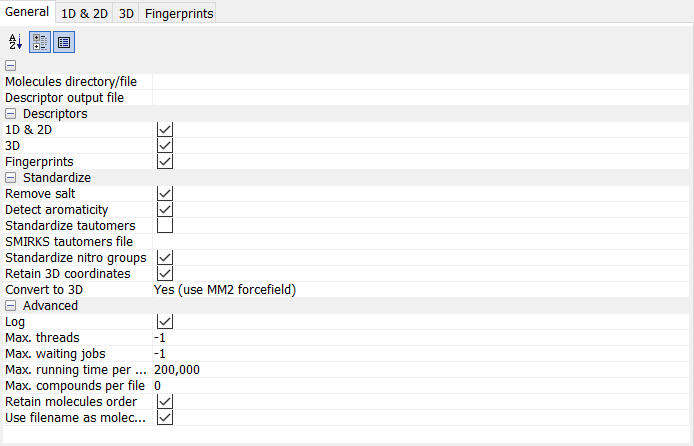

Go through the tabs on the top and **deselect** these descriptors:

- *1D & 2D*
  - Autocorrelation
  - BaryszMatrix
  - BCUT
  - BurdenModifiedEigenvalues
  - ChiChain
  - ChiCluster
  - ChiPathCluster
  - ChiPath
  - DetourMatrix
  - ExtendedTopochemicalAtom
  - InformationContent
  - KappaShapeIndices
  - TopologicalCharge
  - TopologicalDistance Matrix
- *3D*
  - Autocorrelation3D
- *Fingerprints*
  - PubchemFingerprinter
  - Additionally, **select** the box “SubstructureFingerprinterCount”

Going back to the *General* tab, point “Molecules directory/file” to the folder with all the guest molecules. (If you’re getting to this step from CACTUS, select the folder named “guests”). In “Descriptor output file”, select the cdap folder and add “desc.csv” as the file name.

### Reading the descriptors into R

After the results are imported into the variable `desc`, we can begin using the predictive models. Once you have read the descriptors into R check to make sure that the table contains 1377 variables. You can see `desc` in the “Environment” tab in the upper right of the RStudio window, but **do not** click, open, or view the variable as the large size of the table may cause RStudio to crash and/or the R session to abort.

```r
desc <- read.csv("desc.csv", header = T) %>%
  rename(guest = Name) %>%
  mutate(guest = as.character(guest))
```

## Predicting using the models

For predicting complexation with alpha-CD, use the function`predict.alpha`. For beta-CD, use `predict.beta`.

```r
# Predict dG values for alpha- and beta-CD
alpha.results <- predict.alpha(desc)
beta.results <- predict.beta(desc)
```

These two functions actually return a list containing three components. The first component is a simple table with the names of the guest molecules and their predicted dG.

```r
alpha.results[[1]]
```

| guests | dG |
| --- | --- |
| acetaminophen | -11.06416 |
| diethylamine | -10.30664 |
| piroxicam | -12.25369 |

The second goes into more detail, specifying the predicted values for each QSAR. Currently, there are three working models: GLMNet, an SVM with a polynomial kernel, and a Random Forest.

```r
alpha.results[[2]]
```

| guests | glmnet | polysvm | rf | ensemble |
| --- | --- | --- | --- | --- |
| acetaminophen | -10.838206 | -10.95948 | -11.39478 | -11.06416 |
| diethylamine | -9.730786 | -10.32743 | -10.86170 | -10.30664 |
| piroxicam | -13.838695 | -10.67749 | -12.24487 | -12.25369 |

The third is a vector containing outliers, or molecules that fall outside of the applicability domain of at least one of the QSARs. These molecules are too dissimilar to the molecules the models were trained on to produce reliable predictions. As you can see, cinnarizine fails to be predicted accurately by both the alpha-CD and beta-CD models.

```r
alpha.results[[3]]
```

```
[1] "cinnarizine"
```

```r
beta.results[[3]]
```

```
[1] "cinnarizine"
```

We can visualize the results by combining the datasets and graphing them.

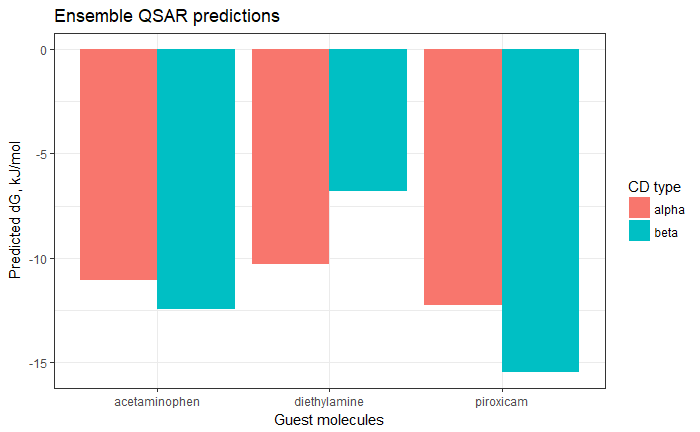

```r
alpha.dg <- alpha.results[[1]] %>% .[order(.$dG), ]
beta.dg <- beta.results[[1]] %>% .[order(.$dG), ]
combined.dg <- rbind(
  mutate(alpha.dg, host = "alpha"),
  mutate(beta.dg, host = "beta")
)
ggplot(combined.dg, aes(x = guests, y = dG, fill = host)) +
  geom_bar(stat = "identity", position = "dodge") +
  theme_bw() +
  labs(x = "Guest molecules",
       y = "Predicted dG, kJ/mol",
       fill = "CD type",
       title = "Ensemble QSAR predictions")
```

To save the data, you can write them into a .RDS (for analysis by R later) or a .csv.

```r
saveRDS(combined.dg, "results.RDS")
write.csv(combined.dg, "results.csv", row.names = F)
```

## General warnings

These models are not able to handle massive molecules such as proteins, polymers, etc. These will almost always fall outside of the applicability domain.